# Exploring read lengths

Ignasi

18/11/2019

```r
library(tidyr)
library(ggplot2)
library(plyr)
library(reactable)

RL <- read.table('ReadLengths.txt', skip = 1,
                 col.names=c("Len","R1","R2","clean1","clean2","single1","single2","merged","not1","not2"))
```

The `ReadLengths.txt` table shows the observed length distribution of different types of reads:

- **R1.** Raw forward reads.
- **R2.** Raw reverse reads.
- **clean1.** Possibly trimmed forward reads from read pairs both ends of which passed the quality filters.
- **clean2.** Possibly trimmed reverse reads from read pairs both ends of which passed the quality filters.
- **single1.** Possibly trimmed forward reads from read pairs the reverse read of which did not pass the quality filters.
- **single2.** Possibly trimmed reverse reads from read pairs the forward read of which did not pass the quality filters.
- **merged.** Read pairs that have been merged, after having passed the filters.
- **not1.** Forward reads from pairs that passed the quality filters but did not get merged.
- **not2.** Reverse reads from pairs that passed the quality filters but did not get merged.

```r
R1 <- sum(RL$R1)
R2 <- sum(RL$R2) # == R1
R1.clean <- sum(RL$clean1)
R2.clean <- sum(RL$clean2) # == R1.clean
R1.single <- sum(RL$single1)
R2.single <- sum(RL$single2) # != R1.single
R1.lost <- R1 - R1.clean - R1.single
R2.lost <- R2 - R2.clean - R2.single
# Partners of lost ends must remain single, unles also lost:
R1.single <= R2.lost
```

```
## [1] TRUE
```

```r
R2.single <= R1.lost
```

```
## [1] TRUE
```

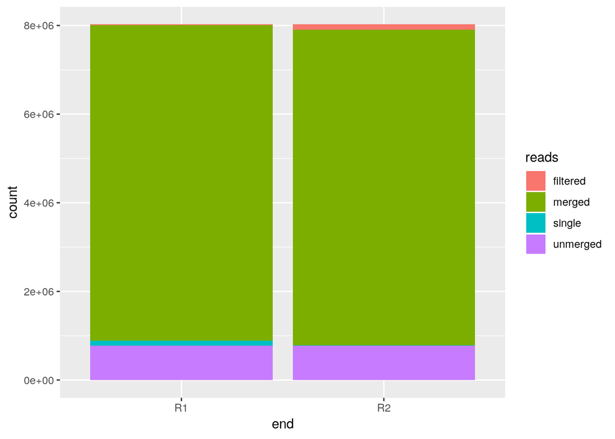

```r
R1.merged <- sum(RL$merged)
R2.merged <- R1.merged
R1.unmerged <- sum(RL$not1)
R2.unmerged <- sum(RL$not2) # == R1.unmerged

Totals <- data.frame(
   merged = c(R1.merged, R2.merged),
   unmerged = c(R1.unmerged, R2.unmerged),
   single = c(R1.single, R2.single),
   filtered = c(R1.lost, R2.lost),
   end = c("R1", "R2"))

Totals_long <- gather(Totals, key='reads', value='count', 1:4)
ggplot(data=Totals_long, mapping=aes(x=end, y=count, fill=reads)) + geom_col()
```

Let’s now take a look at the length distributions.

```r
MeanLen <- function(x, freq){
   T <- sum(freq)
   M <- sum(x * (freq / T))
   return(M)
}
VarLen <- function(x, freq){
   M <- MeanLen(x, freq)
   V <- (1.0 / (sum(freq) - 1.0)) * sum(freq * (x - M)^2)
   return(V)
}

RL_long <- gather(RL, key='Reads', value='Freq', -1)  # all columns, except the first.

ReadLengths <- ddply(RL_long, .variables='Reads', summarize,
                     Mean=round(MeanLen(Len,Freq), 2),
                     Variance=round(VarLen(Len,Freq), 2))
reactable(ReadLengths)
```

| Reads | Mean | Variance |
| --- | --- | --- |
| clean1 | 280.62 | 1986.01 |
| clean2 | 265.9 | 1288.18 |
| merged | 440.74 | 401.19 |
| not1 | 172.32 | 4403.02 |
| not2 | 207.79 | 3331.06 |
| R1 | 299.47 | 68 |
| R2 | 298.53 | 64.59 |
| single1 | 216.53 | 7846 |
| single2 | 201.41 | 4199.59 |

We can visualize length distributions as lines, because data is already frequency. The large differences in frequency among lengths make a logarithmic scale convenient on the y axis. The data being in a wide format, I would use basic plot functions:

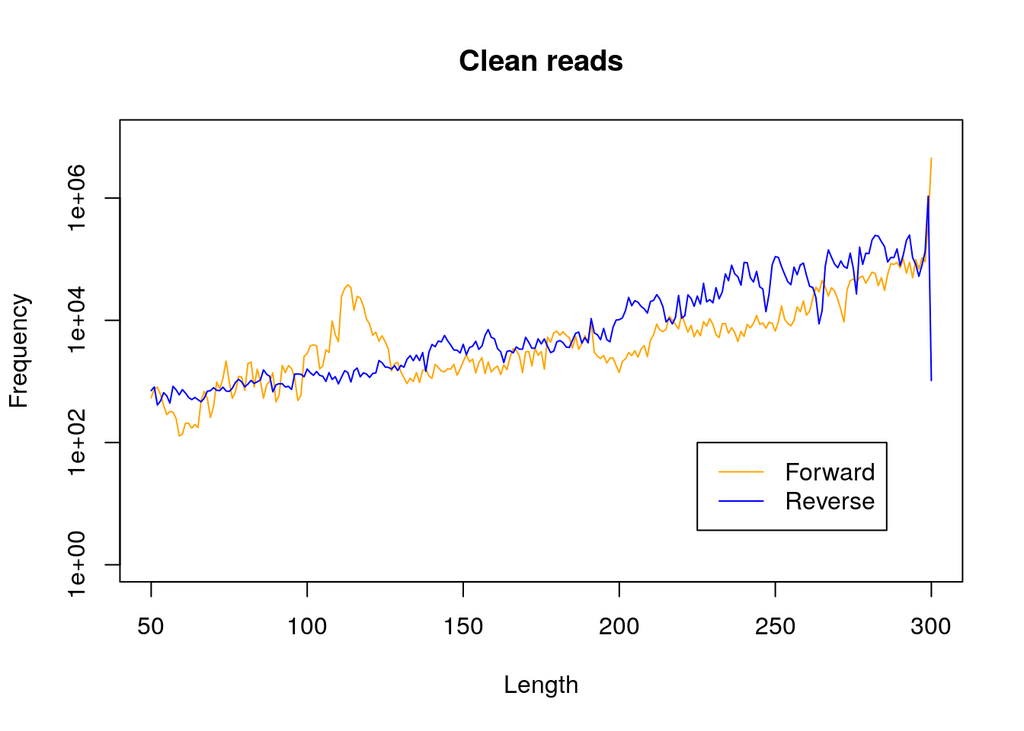

```r
plot(c(50, 300), c(1, 1.0e+7), type='n', xlab='Length', ylab='Frequency', log='y', main='Clean reads')
lines(RL$Len, RL$clean1, col='orange')
lines(RL$Len, RL$clean2, col='blue')
legend(225, 100, legend=c('Forward', 'Reverse'), col=c('orange', 'blue'), lty=c(1,1))
```

To do the same with ggplot2, I use the long format version, created before.

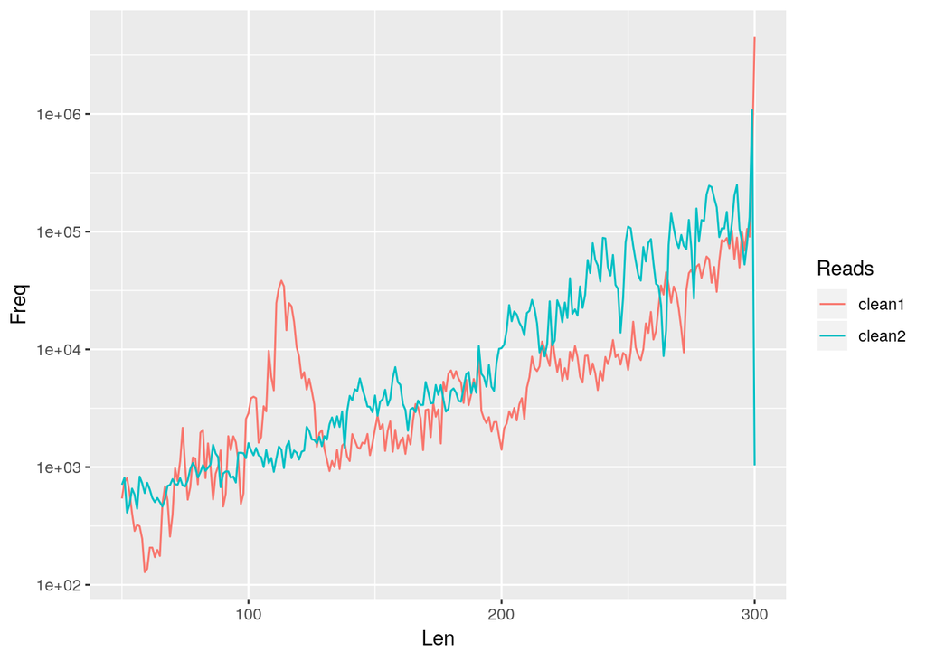

```r
ggplot(data=RL_long[RL_long$Reads %in% c('clean1','clean2'),],
       mapping=aes(x=Len, y=Freq, color=Reads)) +
  geom_line() + scale_y_log10() + xlim(50,300)
```

The following plot makes it evident that the reads that did not get merged are but a subset of those that passed the quality control.

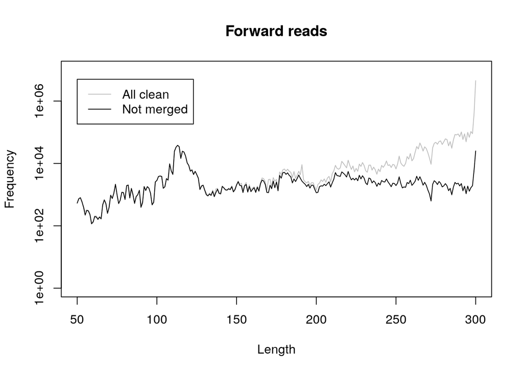

```r
plot(c(50,300), c(1,1.0e+7), type='n', xlab='Length', ylab='Frequency', log='y', main='Forward reads')
lines(RL$Len, RL$clean1, col='gray')
lines(RL$Len, RL$not1)
legend(50, 5.0e+6, legend=c('All clean', 'Not merged'), col=c('gray', 'black'), lty=c(1,1))
```

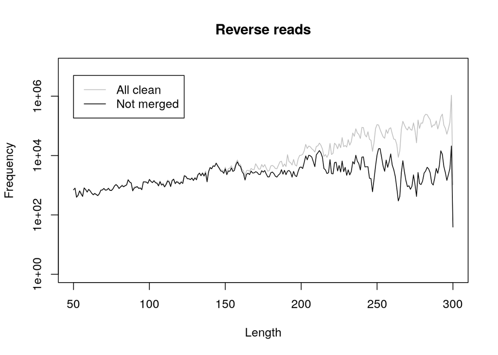

```r
plot(c(50,300), c(1,1.0e+7), type='n', xlab='Length', ylab='Frequency', log='y', main='Reverse reads')
lines(RL$Len, RL$clean2, col='gray')
lines(RL$Len, RL$not2)
legend(50, 5.0e+6, legend=c('All clean', 'Not merged'), col=c('gray', 'black'), lty=c(1,1))
```

Maybe the most interesting plot is the length distribution of merged reads.

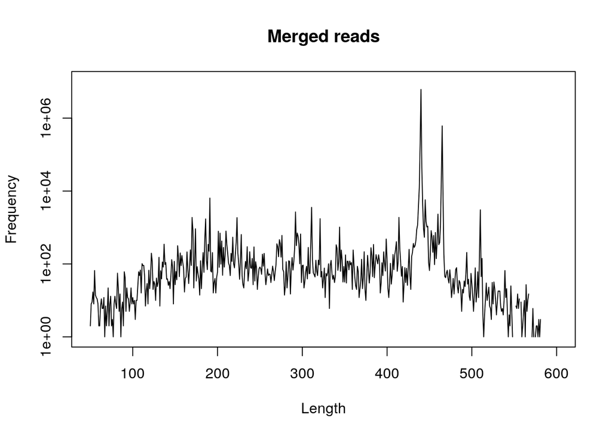

```r
plot(c(50,600), c(1, 1.0e+7), type='n', xlab='Length', ylab='Frequency', log='y', main='Merged reads')
lines(RL$Len, RL$merged)
```